# Outlier Cleaning

Outliers were thoroughly cleaned from the NMIS data set before running the analysis portion of our R scripts. In this section, we will explore both the outlier **detection** and **replacement** processes.

#### Reading in Our Special Data: RDS files

Please download the pre-outlier cleaned education data set here: [edu data](https://www.dropbox.com/s/plojzyei3g3layi/Education_774_normalized.rds).

As you can see, the file you downloaded is in .RDS format. This file type can only be opened using R. The main purpouse for this file format is **speed**. R reads in and writes out .RDS files significantly faster than any other file type, which is important when working with larger data sets such as NMIS.

Let's take this opportunity now to learn two new commands that are nearly identical to `read.csv()` and `write.csv()`: **readRDS()** and **saveRDS()**.

```r
edu_normalized <- readRDS("~/Dropbox/Nigeria/Nigeria 661 Baseline Data Cleaning/in_process_data/Normalized/Education_774_normalized.rds")
```

```r
saveRDS(edu_normalized, "~/Desktop/Education_Normalized_unchanged.RDS")
```

#### Outlier Detection Example

We can start by seeing a simple example of outlier removal using logic Checks. Frequently, we run basic logic checks on the data as part of the cleaning process.

```r
function(df, c, rowpredicate, replaceVal=NA)
```

```r
edu_normalized <- outlierreplace(edu_normalized, "num_tchrs_male", (edu_normalized$num_tchrs_male >
    edu_normalized$num_tchrs_total))
```

#### The Function: **outlierreplace()**

Now that you've seen an example of the function, let's step back and break down the `outlierreplace` function line by line. Because our functions are not in an official R package, you cannot access the help manual as you learned in Day 1.

```r
# stringr library is necessary for our function
library(stringr)

# the function
outlierreplace = function(df, c, rowpredicate, replaceVal = NA) {
    naCount1 <- sum(is.na(df[, c]))
    df[, c] <- replace(df[, c], rowpredicate, replaceVal)
    naCount2 <- sum(is.na(df[, c]))
    print(str_c(naCount2 - naCount1, " outliers replaced for field: ", c))
    df
}

head(edu_normalized$num_tchrs_male > edu_normalized$num_tchrs_total)
```

```
## [1] FALSE FALSE FALSE FALSE FALSE FALSE
```

Questions:

- Let's say we no longer wish to print the number of outliers replaced - what would you change in the function?
- Can you make the outliers take on 0 as a value instead of NA?

#### Outlier Removal with a Numerical Threshold

By setting a certain threshold, we can eliminate a range of outliers with one use of the function.

```r
summary(edu_normalized$num_students_female)
```

```
##    Min. 1st Qu.  Median    Mean 3rd Qu.    Max.    NA's
##       0      50     105     204     218 1000000     344
```

```r
edu_normalized <- outlierreplace(edu_normalized, "num_students_female", (edu_normalized$num_students_female >
    3000))
```

```
## [1] "49 outliers replaced for field: num_students_female"
```

```r
summary(edu_normalized$num_students_female)
```

```
##    Min. 1st Qu.  Median    Mean 3rd Qu.    Max.    NA's
##       0      50     105     187     217    3000     393
```

The alternative would be to write a function equal to each individual value i.e. `rowpredicate` being edu_normalized$num_students_female == 3000 etc. etc.

Notice that there may be multiple variables in the `rowpredicate` conditions.

```r
edu_normalized <- outlierreplace(edu_normalized, "num_js_female", (edu_normalized$num_js_female >
    1250 & edu_normalized$num_classrms_total < 25 & edu_normalized$num_tchrs_total <
    10))
```

```
## [1] "3 outliers replaced for field: num_js_female"
```

Upon inspection of the summary statistics for certain columns, outliers can become obviously clear.

```r
summary(edu_normalized$num_exercise_books_per_student_pry)
```

```
##    Min. 1st Qu.  Median    Mean 3rd Qu.    Max.    NA's
##       0      84     262     724     714   70800   63993
```

```r
summary(edu_normalized$num_exercise_books_per_student_jss)
```

```
##    Min. 1st Qu.  Median    Mean 3rd Qu.    Max.    NA's
##       0      60     570    1800    1730   34700   68474
```

Question: Where should we set a threshold?

- Let's take a look at the **sample_data** we worked with in previous trainings. Detect and eliminate any outliers for the `num_doctors_available` variable. Hint: if you get stuck about how to set the `rowpredicate` conditions, remember the `table()` function.

#### A Graphical Example

To find a more precise threshold than using the summary/table method, we can plot our data.

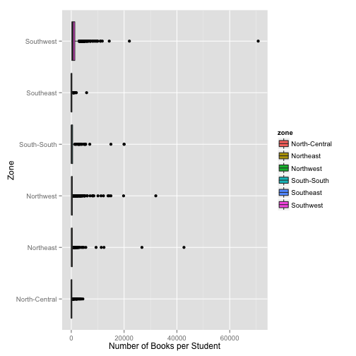

```r
library(ggplot2)

ggplot(edu_normalized, aes(x = zone, y = num_exercise_books_per_student_pry,
    fill = zone)) + geom_boxplot() + coord_flip() + ylab("Number of Books per Student") +
    xlab("Zone")  #+ scale_y_continuous(limits=c(0,3000))
```

The above graph demonstrates the magnitude of the outliers present for the `num_exercise_books_per_student_pry` variable. By adjusting the scale of our graph, we can have a more precise picture of where to establish our threshold:

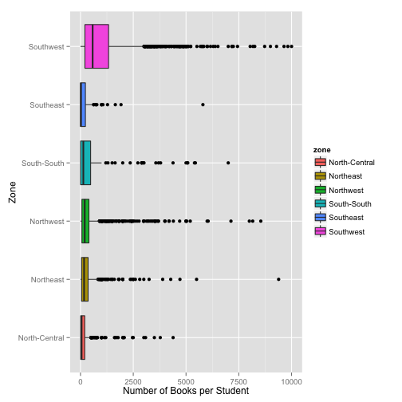

```r
library(ggplot2)

ggplot(edu_normalized, aes(x = zone, y = num_exercise_books_per_student_pry,
    fill = zone)) + geom_boxplot() + coord_flip() + ylab("Number of Books per Student") +
    xlab("Zone") + scale_y_continuous(limits = c(0, 10000))
```